# Experiment with the king of France: Topics, verifiability and definite description

Mina Bakharzi, Conor McCullough, Vasilena Voynikova

20.07.2018

**Abstract**

## Introduction

Russell (1905, 1957) stated that sentences with definite descriptions require the existence of an individual that satisfies the description. If such an individual does not exist (1), the sentence is assessed as FALSE.

1. *The king of France is bald.*

On the contrary, Strawson (1950, 1964) argued that Russell’s theory cannot predict why participants feel ‘squeamish’ (unsure) when assigning the truth-value (the attribute assigned to a proposition in respect of its truth or falsehood, which in classical logic has only two possible values - true or false) false to sentences as the example in (1). According to him, definite descriptions presuppose the existence of a unique individual that satisfies the description. In case the presupposition is not met, the sentence does not have a truth-value.

Strawson (1964) mentioned that depending on different contexts, the truth-values can change. He was of the opinion that instances as in (2) seem to be straightforwardly FALSE.

2. *The exhibition was visited yesterday by the King of France.*

Strawson (1964) together with other researchers have reached the conclusion that the topicality of a structure may play a crucial role. Others (Lasersohn, 1993,Von Fintel (2004)) believe that background knowledge is of great importance. Our intuitions about about accepting or rejecting a sentence as true or false, and the sentence’s actual semantic truth-value (hence presuppositionality) are two separate things. Speakers may regard a sentence as TRUE or FALSE, even though it has no truth-value, if they are able to find a reason to accept or reject it (Lasersohn, 1993).

3. *The King of France is sitting in this chair.*

In this case, sitting in front of a chair which is either empty, or taken by a person other than the King of France (regardless of whether or not he exists), naturally leads one to reject the sentence as FALSE. Referring back to Example (1), if there is an absence of background knowledge about the hairstyle of the French royals, participants do not have evidence to reject or accept the sentence, and one is left with the feeling of ‘squeamishness’ (uncertainty).

There is also a third option proposed by Stalnaker (1974) suggesting that sentences with definite descriptions require the existence of an individual who can satisfy the description, as well as, require that the existence of a unique referent be presupposed.

Our main aim is to investigate the truth-value intuitions reported in the literature in an experimental setting. To do so, a behavioural experiment was conducted which was designed to take hold of and evaluate people’s intuitions about sentences, such as (1) and (2). It was hypothesised that when a noun phrase (e.g. ‘the King of France’) is topical (as in Example (1) above), it leads to a presupposition failure. If the same noun phrase is not topical (as in Example (2) above) - (the topic being ‘The exhibition’) - it seems to be absorbed into the predicate and as a result the sentence is regarded as FALSE. In other words, only propositions which are in accordance or in a conflict with the given information are predicted to have a truth-value (TRUE/FALSE).

Indeed, we have found that truth-value intuitions depend heavily on the nature and structure of the sentence in which they appear. It was observed that both the topic structure of a sentence (Strawson, 1964) and its verifiability (Lasersohn, 1993,Von Fintel (2004)) are essential factors influencing the truth-value intuitions.

## Method

### Materials

The experiment was available online. Participants were sent the link to the website and given access to it. They were instructed to sit comfortably in front of the computer and were introduced to the following task. All of the participants were allocated to the same experiment and stimuli. In the beginning, they were first presented with instructions and a practice session followed, consisting of five practice trials (Appendix A). Afterwards, the main experimental session came, including a total of 165 trials (there were eleven test conditions (Appendix B), with five test items (Appendix C) in each condition (a total of 55 trials), together with twice as many (~110) filler sentences), separated into two blocks. Some of the statements used were taken from previous research papers (Abrusán & Szendroi, 2013), the rest were formulated for the current experiment. Subjects were restricted in time neither during the practice, nor during the main session. They could read each statement and answer at their own pace. Although they were encouraged to not overthink, rather to read as quickly as they could and answer according to their initial thoughts. To each of the statements in the sessions, they could answer by clicking on one of three button options (‘TRUE’, ‘FALSE’, ‘CAN’T SAY’) by a mouse click. Button randomisation took place prior to each and every experiment. In other words, the three option buttons that the participants could choose from (TRUE, CAN’T SAY, FALSE), were distributed in a different arrangement. Between the two blocks in the experimental session, participants were given time to have a short break. They were able to continue to the next block of trials by a mouse click.

### Design

A within-subjects design was used. The independent variable was the different stimuli the participants were presented with (55 trial items, resulting from eleven test conditions, with five test items in each condition) and the dependent variable was the response option (‘TRUE’, ‘FALSE’, ‘CAN’T SAY’). This type of design was favoured in order to avoid individual differences.

### Procedure

After participants were given information about the purpose, duration and procedure of the experiment, by clicking a button to proceed with it, they gave their consent to participating in this experiment. Subjects were also reminded that withdrawal at any time would not be followed by future consequences and their data storage will be anonymous. Experimenters’ contact details were also provided.

Then, further instructions regarding the task were given. Participants were informed that a session with practice trials comes first, followed by the main experimental session, divided in two blocks, between which subjects would be able to have a short break. They could proceed to the next trial/block of trials with a click of the mouse. Subjects were not restricted in time neither in the practice, nor in the main session. Participants were made aware that they could read each statement and answer at their own pace. Although they were encouraged to read as fast as they could and answer according to their initial thoughts. To each of the items, they could answer clicking on one of three button options (‘TRUE’, ‘FALSE’, ‘CAN’T SAY’) by a mouse click.

Participants’ personal information (age, gender, mother tongue/s), as well as further recommendation/comments (if applicable) were provided at the end of the experiment. In the end, they were debriefed and given more information about the study. All the information was recorded by the experimenters.

## Results

**Condition 0** was the baseline (e.g. The King of France is bald), containing a reference failure NP, without any other NP in the predicate, the correct answer would be FALSE. Based on the many theories stating that this would result in mostly FALSE answer, we predicted the same. The result certainly agreed with our prediction; approx. 70% of answers for this condition were FALSE, less than 10% believed it to be TRUE. When compared to the other conditions, we see that C0 is statistically significant to C1, C3, C4, C6 and C10.

**Condition 1** - ‘France has a king and he is bald.’- is a FALSE statement, and contains the presupposition that France has a king. Anyone who knows that France has no king, we predicted would click FALSE, and this was clearly seen in the results, with very similar data to that of C0. With regards to its comparison to other conditions, C1 is statistically significant to C0, C3, C4, C5, C6 and C10.

**Conditions 6—10** are the same as Conditions 0 and 2—5, except they are negated. When predicting the results for C6—10, we assumed that if their positive counterparts (C0—5) were mostly judged FALSE due to a pragmatic rejection of a statement rather than a semantic one, then the negated versions should not then result in TRUE judgements. Thus we predicted that C6—10, would result in more FALSE judgements. What we actually discovered was a clear decrease in FALSE judgements, and an increase in TRUE. There is a clear increase in TRUE judgments in all negated sentences, when compared with their positive versions.

### Data preparation and exploration

First we load some necessary packages:

```r
library(tidyverse)
library(ordinal) # for ordinal logistic regression
```

Then, read, massage and filter the data (only main trials):

```r
d = read.csv('C:/Users/Lenovo/Desktop/now.csv') %>%
  mutate(condition = factor(condition, ordered = T, levels = seq(0,10)),
         option_chosen = factor(option_chosen, ordered = T, levels = c("false", "cantsay", "true")))
```

### Data cleaning and summary statistics

Prior to plotting the data, we state how it should look like (we want to plot conditions to proportion of options chosen):

```r
plotData = d %>% filter(condition %in% seq(0,10)) %>%
  select(condition, option_chosen) %>%
  group_by(condition) %>%
  mutate(total_obs = n()) %>%
  ungroup() %>%
  group_by(condition, option_chosen) %>%
  summarize(proportion = n() / total_obs[1]) %>%
  arrange(condition, option_chosen)
```

Summary statistics, which we will also use for plotting:

```r
## test data
testData = d %>% filter(condition %in% seq(0,10)) %>% as.tibble() %>%
  mutate(negation = condition >=6) %>%
  select(condition, option_chosen, negation, submission_id)

# compare all conditions against the reference level C0
colnames(contrasts(testData$condition)) = paste0(".C",levels(testData$condition)[-1])
clm(data = testData,
    formula = option_chosen ~ condition) %>% summary()
```

```
## formula: option_chosen ~ condition
## data:    testData
##
##  link  threshold nobs logLik  AIC     niter max.grad cond.H
##  logit flexible  755  -683.41 1390.83 5(0)  8.12e-14 1.7e+01
##
## Coefficients:
##               Estimate Std. Error z value Pr(>|z|)
## condition.C1   3.10408    0.25518  12.164  < 2e-16 ***
## condition.C2   0.43747    0.23559   1.857  0.06332 .
## condition.C3  -1.08534    0.24218  -4.482 7.41e-06 ***
## condition.C4  -0.73438    0.24342  -3.017  0.00255 **
## condition.C5   0.47951    0.24530   1.955  0.05061 .
## condition.C6   0.69734    0.24700   2.823  0.00475 **
## condition.C7  -0.05961    0.24942  -0.239  0.81111
## condition.C8   0.42893    0.24814   1.729  0.08389 .
## condition.C9   0.41023    0.24767   1.656  0.09765 .
## condition.C10  0.53571    0.24277   2.207  0.02734 *
## ---
## Signif. codes:  0 '***' 0.001 '**' 0.01 '*' 0.05 '.' 0.1 ' ' 1
##
## Threshold coefficients:
##               Estimate Std. Error z value
## false|cantsay -0.22314    0.08246  -2.706
## cantsay|true   1.58524    0.10235  15.488
```

```r
# compare positive and negated conditions
clm(data = testData,
    formula = option_chosen ~ negation) %>% summary()
```

```
## formula: option_chosen ~ negation
## data:    testData
##
##  link  threshold nobs logLik  AIC     niter max.grad cond.H
##  logit flexible  755  -692.78 1391.56 5(0)  3.70e-13 9.3e+00
##
## Coefficients:
##              Estimate Std. Error z value Pr(>|z|)
## negationTRUE   2.0003     0.1555   12.86   <2e-16 ***
## ---
## Signif. codes:  0 '***' 0.001 '**' 0.01 '*' 0.05 '.' 0.1 ' ' 1
##
## Threshold coefficients:
##               Estimate Std. Error z value
## false|cantsay   0.7138     0.1005   7.101
## cantsay|true    2.4811     0.1379  17.995
```

### Data plotting

We can then plot the distribution of responses for each condition:

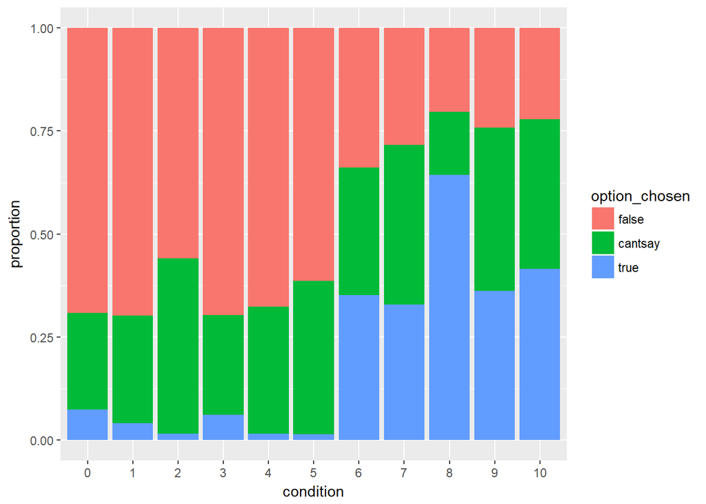

```r
ggplot(plotData,
       aes(x = condition, y = proportion, fill = option_chosen)) +
  geom_bar(stat = "identity")
```

### Statistical analysis

We make use of logistic regression to analyse the data, as our dependent variable appears to be of categorical type (3 response categories - TRUE, FALSE, CAN’T SAY).

```r
# compare all conditions against the reference level C0
colnames(contrasts(testData$condition)) = paste0(".C",levels(testData$condition)[-1])
clm(data = testData,
    formula = option_chosen ~ condition) %>% summary()
```

```
## formula: option_chosen ~ condition
## data:    testData
##
##  link  threshold nobs logLik  AIC     niter max.grad cond.H
##  logit flexible  755  -683.41 1390.83 5(0)  8.12e-14 1.7e+01
##
## Coefficients:
##               Estimate Std. Error z value Pr(>|z|)
## condition.C1   3.10408    0.25518  12.164  < 2e-16 ***
## condition.C2   0.43747    0.23559   1.857  0.06332 .
## condition.C3  -1.08534    0.24218  -4.482 7.41e-06 ***
## condition.C4  -0.73438    0.24342  -3.017  0.00255 **
## condition.C5   0.47951    0.24530   1.955  0.05061 .
## condition.C6   0.69734    0.24700   2.823  0.00475 **
## condition.C7  -0.05961    0.24942  -0.239  0.81111
## condition.C8   0.42893    0.24814   1.729  0.08389 .
## condition.C9   0.41023    0.24767   1.656  0.09765 .
## condition.C10  0.53571    0.24277   2.207  0.02734 *
## ---
## Signif. codes:  0 '***' 0.001 '**' 0.01 '*' 0.05 '.' 0.1 ' ' 1
##
## Threshold coefficients:
##               Estimate Std. Error z value
## false|cantsay -0.22314    0.08246  -2.706
## cantsay|true   1.58524    0.10235  15.488
```

## Discussion

In order to make sure that any ‘CAN’T SAY’-judgment in Condition 0 is due to the participants’ awareness of the lack of referent for our definite descriptions and not due to the fact that the statement was beyond their knowledge, a control condition was included, Condition 1. Here the existential presupposition associated with the noun phrase is formulated as an assertion (e.g. ‘France has a king and he is bald.’). Therefore, anyone who knows that France does not have a king is expected to press ‘FALSE’ as an answer.

Condition 2 aims at testing von Fintel’s hypothesis (2004). According to Von Fintel’s (2004), there will be a higher number of ‘FALSE’ judgments in this condition than in Condition 0, because of the presence of an independent noun phrase which would provide a foothold for verification of the truth-value of the statement.

Condition 3 is designed to test Lasersohn’s theory (1993) and is predicted that there would be more ‘FALSE’ judgements in Condition 3 than in Condition 0.

Conditions 6-10 corresponded to Conditions 0, 2-5, respectively, but involved sentential negation. Our core assumption was that if a ‘FALSE’ judgment in our positive conditions arises not on the basis of the utterance being considered semantically false, but rather as a result of some kind of pragmatic rejection of a particular statement, then the judgment of the negation of that utterance should not turn into a ‘TRUE’ judgment. This is because rejecting an utterance does not necessarily equal a willingness to accept its negated version. Here is an example:

4. *A. The King of France is bald.*  
   *B. The King of France is not bold.*

If the reason why (4A) is judged to be ‘FALSE’ is not because it has the semantic value 0, then (4B) should not be judged as ‘TRUE’. Thus, a low proportion of ‘TRUE’ judgments was expected for Condition 6.

Condition 7, the negated version of Condition 2. According to von Fintel’s theory (2004), a higher number of ‘TRUE’ judgements is to be observed in Condition 7 than in Condition 6.

Lasersohn (1993) predicted a higher number of ‘TRUE’ judgments in Condition 8, the negated version of Condition 3, than our negative baseline, Condition 6.

Finally, Strawson (1964) predicted higher number of ‘TRUE’ judgments in Condition 10 than in Condition 9, which are the negated equivalents of Conditions 5 and 4, respectively.

## Conclusion

In summary, it was confirmed that different truth-value intuitions have been extracted from definite descriptions with reference failure depending on the local linguistic context. We found that pragmatic strategies dependent on verification and topicalization play a role in people’s subjective judgements.

## References

Abrusán, M., & Szendroi, K. (2013). Experimenting with the king of france–Topics, verifiability and definite descriptions. *Semantics and Pragmatics*, *6*(10), 1–43.

Lasersohn, P. (1993). Existence presuppositions and background knowledge. *Journal of Semantics*, *10*(2), 113–122.

Russell, B. (1905). On denoting. mind xiv (4). 479–493.

Russell, B. (1957). Mr. strawson on referring. *Mind*, *66*(263), 385–389.

Stalnaker, R. (1974). Pragmatic presuppositions. semantics and philosophy, ed. by milton k. munitz and peter unger, 197–213. New York: New York University Press.

Strawson, P. F. (1950). On referring. *Mind*, *59*(235), 320–344.

Strawson, P. F. (1964). Identifying reference and truth-values. *Theoria*, *30*(2), 96–118.

Von Fintel, K. (2004). *Would you believe it? The king of france is back!(Presuppositions and truth-value intuitions)*. na.

## Appendices

### Appendix A

Table with the sentences which were part of the practice trials.

> 1. Spain is a country in Asia.
> 2. Normally there are 32 teeth in the adult human body.
> 3. Alexander Bell invented the telephone.
> 4. World War II was a global war that lasted from 1914 to 1918.
> 5. William Shakespeare was an English poet, playwright and actor, regarded as the greatest writer in the English language.

### Appendix B

Table with the sentences which were part of the main experimental trials.

[output not shown]

### Appendix C

Table with the sentences which were part of the test trials.

> 1. France has a king.
> 2. The Pope is currently not married.
> 3. Canada is a democracy.
> 4. Belgium has rainforests.
> 5. Germany has volcanoes.